# R4DS_2E_functions

Martin

2026-01-19

## Functions - Vector functions

1. Practice turning the following code snippets into functions. Think about what each function does. What would you call it? How many arguments does it need?

```r
mean(is.na(x))
```

```
## Error: object 'x' not found
```

```r
mean(is.na(y))
```

```
## Error: object 'y' not found
```

```r
mean(is.na(z))
```

```
## Error: object 'z' not found
```

```r
# These tell us the average number of missing values, so I would call it avg_missing. It should only take a single value as it's providing a summary

avg_missing <- function(x) {
  mean(is.na(x))
}

x / sum(x, na.rm = TRUE)
```

```
## Error: object 'x' not found
```

```r
y / sum(y, na.rm = TRUE)
```

```
## Error: object 'y' not found
```

```r
z / sum(z, na.rm = TRUE)
```

```
## Error: object 'z' not found
```

```r
# Divides each value of a vector by the total sum of all of its values. Essentially its calculating the proportion of each value

val_prop <- function(x) {
  x / sum(x, na.rm = TRUE)
}

x <- c(3, 5, 15)
val_prop(x)
```

```
## [1] 0.1304348 0.2173913 0.6521739
```

```r
round(x / sum(x, na.rm = TRUE) * 100, 1)
```

```
## [1] 13.0 21.7 65.2
```

```r
round(y / sum(y, na.rm = TRUE) * 100, 1)
```

```
## Error: object 'y' not found
```

```r
round(z / sum(z, na.rm = TRUE) * 100, 1)
```

```
## Error: object 'z' not found
```

```r
# Does the same as above but now multiplies the proportion by 100 and rounds to the nearest 1 d.p.

val_rprop <- function(x) {
  round(x / sum(x, na.rm = TRUE) * 100, 1)
}
```

2. In the second variant of rescale01(), infinite values are left unchanged. Can you rewrite rescale01() so that -Inf is mapped to 0, and Inf is mapped to 1?

```r
# The code as it was in the book:
rescale01 <- function(x) {
  rng <- range(x, na.rm = TRUE, finite = TRUE)
  (x - rng[1]) / (rng[2] - rng[1])
}

rescale02 <- function(x) {
  x <- case_when(
    x == -Inf ~ 0,
    x == Inf ~ 1,
    .default = x
  )
  rng <- range(x, na.rm = TRUE)
  (x - rng[1]) / (rng[2] - rng[1])
}

x <- c(-Inf, -3:3, Inf)
x
```

```
## [1] -Inf   -3   -2   -1    0    1    2    3  Inf
```

```r
rescale01(x)
```

```
## [1]      -Inf 0.0000000 0.1666667 0.3333333 0.5000000 0.6666667 0.8333333
## [8] 1.0000000       Inf
```

```r
rescale02(x)
```

```
## [1] 0.5000000 0.0000000 0.1666667 0.3333333 0.5000000 0.6666667 0.8333333
## [8] 1.0000000 0.6666667
```

3. Given a vector of birthdates, write a function to compute the age in years.

```r
birthdates <- c("01/02/1994", "05-12-2002", "30 4 1945")
lubridate::dmy(birthdates)
```

```
## [1] "1994-02-01" "2002-12-05" "1945-04-30"
```

```r
today() - lubridate::dmy(birthdates)
```

```
## Time differences in days
## [1] 11675  8446 29484
```

```r
age_dmy <- function(bdays) {
  age <- today() - lubridate::dmy(bdays)
  as.duration(age)
}

ages <- age_dmy(birthdates)
View(ages)
```

4. Write your own functions to compute the variance and skewness of a numeric vector. You can look up the definitions on Wikipedia or elsewhere.

```r
myvar <- function(x) {
  sum((x - mean(x, na.rm = TRUE))^2) / length(x)
}

x <- c(1, 2, 3, 5)
myvar(x)
```

```
## [1] 2.1875
```

```r
skew <- function(x) {
  sd <- sqrt(myvar(x))
  sum((x - mean(x))^3) / (length(x) - 1) * sd^3
}

skew(x)
```

```
## [1] 6.066293
```

5. Write both_na(), a summary function that takes two vectors of the same length and returns the number of positions that have an NA in both vectors.

```r
x <- c(1, 3, 5, NA, NA, 5)
y <- c(NA, 3, 2, NA, NA, 5)

both_na <- function(x, y) {
  if (length(x) != length(y)) {
    return("Both vectors must be the same length")
  }

  which(is.na(x) & is.na(y))
}

both_na(x, y)
```

```
## [1] 4 5
```

6. Read the documentation to figure out what the following functions do. Why are they useful even though they are so short?

```r
is_directory <- function(x) {
  file.info(x)$isdir
}
is_readable <- function(x) {
  file.access(x, 4) == 0
}

# is_directory appears to tell us whether the supplied directory path is an existing directory on your computer. This is definitely helpful when wanting to read/write files.
is_directory("C:/Users/M/OneDrive/Documents")
```

```
## [1] NA
```

```r
is_directory("C:/Users/M/OneDrive/Documents/ThisDoesntExist")
```

```
## [1] NA
```

```r
# It's using information from `file.info` and subsetting by the `isdir` column
file.info("C:/Users/M/OneDrive/Documents")
```

```
##                               size isdir mode mtime ctime atime  exe uname
## C:/Users/M/OneDrive/Documents   NA    NA <NA>  <NA>  <NA>  <NA> <NA>
##                               udomain
## C:/Users/M/OneDrive/Documents
```

```r
file.info("C:/Users/M/OneDrive/Documents/ThisDoesntExist")
```

```
##                                               size isdir mode mtime ctime atime
## C:/Users/M/OneDrive/Documents/ThisDoesntExist   NA    NA <NA>  <NA>  <NA>  <NA>
##                                                exe uname udomain
## C:/Users/M/OneDrive/Documents/ThisDoesntExist <NA>
```

```r
# Another self-explanatory function, checks if a file is readable. Uses `file.access` which `mode = 4` which just tests for read permission. The reason for the equality check is that `file.access` will return 0 for success and -1 for failure.
is_readable("C:/Users/M/OneDrive/Documents")
```

```
## C:/Users/M/OneDrive/Documents
##                         FALSE
```

```r
file.access("C:/Users/M/OneDrive/Documents", mode = 4)
```

```
## C:/Users/M/OneDrive/Documents
##                            -1
```

```r
file.access("C:/Users/M/OneDrive/Documents/ThisDoesntExist", mode = 4)
```

```
## C:/Users/M/OneDrive/Documents/ThisDoesntExist
##                                            -1
```

## Functions - Dataframe functions

1. Using the datasets from nycflights13, write a function that:

Finds all flights that were cancelled (i.e. is.na(arr_time)) or delayed by more than an hour. Something like `flights |> filter_severe()`

```r
flights |>
  filter(is.na(arr_time) | dep_delay >= 60)
```

```
## # A tibble: 35,615 × 19
##     year month   day dep_time sched_dep_time dep_delay arr_time sched_arr_time
##    <int> <int> <int>    <int>          <int>     <dbl>    <int>          <int>
##  1  2013     1     1      811            630       101     1047            830
##  2  2013     1     1      826            715        71     1136           1045
##  3  2013     1     1      848           1835       853     1001           1950
##  4  2013     1     1      957            733       144     1056            853
##  5  2013     1     1     1114            900       134     1447           1222
##  6  2013     1     1     1120            944        96     1331           1213
##  7  2013     1     1     1301           1150        71     1518           1345
##  8  2013     1     1     1337           1220        77     1649           1531
##  9  2013     1     1     1400           1250        70     1645           1502
## 10  2013     1     1     1505           1310       115     1638           1431
## # ℹ 35,605 more rows
## # ℹ 11 more variables: arr_delay <dbl>, carrier <chr>, flight <int>,
## #   tailnum <chr>, origin <chr>, dest <chr>, air_time <dbl>, distance <dbl>,
## #   hour <dbl>, minute <dbl>, time_hour <dttm>
```

```r
filter_severe <- function(df) {
  df |>
    filter(is.na(arr_time) | dep_delay >= 60)
}

flights |>
  filter_severe()
```

```
## # A tibble: 35,615 × 19
##     year month   day dep_time sched_dep_time dep_delay arr_time sched_arr_time
##    <int> <int> <int>    <int>          <int>     <dbl>    <int>          <int>
##  1  2013     1     1      811            630       101     1047            830
##  2  2013     1     1      826            715        71     1136           1045
##  3  2013     1     1      848           1835       853     1001           1950
##  4  2013     1     1      957            733       144     1056            853
##  5  2013     1     1     1114            900       134     1447           1222
##  6  2013     1     1     1120            944        96     1331           1213
##  7  2013     1     1     1301           1150        71     1518           1345
##  8  2013     1     1     1337           1220        77     1649           1531
##  9  2013     1     1     1400           1250        70     1645           1502
## 10  2013     1     1     1505           1310       115     1638           1431
## # ℹ 35,605 more rows
## # ℹ 11 more variables: arr_delay <dbl>, carrier <chr>, flight <int>,
## #   tailnum <chr>, origin <chr>, dest <chr>, air_time <dbl>, distance <dbl>,
## #   hour <dbl>, minute <dbl>, time_hour <dttm>
```

2. Counts the number of cancelled flights and the number of flights delayed by more than an hour.

```r
summarize_severe <- function(df) {
  df |>
    summarize(
      n_cancelled = sum(is.na(arr_time)),
      n_big_delay = sum(dep_delay >= 60, na.rm = TRUE),
      .groups = "drop"
    )
}

flights |>
  group_by(dest) |>
  summarize_severe()
```

```
## # A tibble: 105 × 3
##    dest  n_cancelled n_big_delay
##    <chr>       <int>       <int>
##  1 ABQ             0          21
##  2 ACK             0          12
##  3 ALB            21          65
##  4 ANC             0           1
##  5 ATL           342        1310
##  6 AUS            22         184
##  7 AVL            12          17
##  8 BDL            31          52
##  9 BGR            17          51
## 10 BHM            28          51
## # ℹ 95 more rows
```

3. Finds all flights that were cancelled or delayed by more than a user supplied number of hours:

```r
filter_severe <- function(df, hours) {
  df |>
    filter(is.na(arr_time) | dep_delay >= hours * 60)
}

flights |>
  filter_severe(hours = 3)
```

```
## # A tibble: 12,615 × 19
##     year month   day dep_time sched_dep_time dep_delay arr_time sched_arr_time
##    <int> <int> <int>    <int>          <int>     <dbl>    <int>          <int>
##  1  2013     1     1      848           1835       853     1001           1950
##  2  2013     1     1     1815           1325       290     2120           1542
##  3  2013     1     1     1842           1422       260     1958           1535
##  4  2013     1     1     2006           1630       216     2230           1848
##  5  2013     1     1     2016           1930        46       NA           2220
##  6  2013     1     1     2115           1700       255     2330           1920
##  7  2013     1     1     2205           1720       285       46           2040
##  8  2013     1     1     2312           2000       192       21           2110
##  9  2013     1     1     2343           1724       379      314           1938
## 10  2013     1     1       NA           1630        NA       NA           1815
## # ℹ 12,605 more rows
## # ℹ 11 more variables: arr_delay <dbl>, carrier <chr>, flight <int>,
## #   tailnum <chr>, origin <chr>, dest <chr>, air_time <dbl>, distance <dbl>,
## #   hour <dbl>, minute <dbl>, time_hour <dttm>
```

4. Summarize the weather to compute the minimum, mean, and maximum, of a user supplied variable:

```r
summarize_weather <- function(df, var) {
  df |>
    summarize(
      min = min({{ var }}, na.rm = TRUE),
      mean = mean({{ var }}, na.rm = TRUE),
      max = max({{ var }}, na.rm = TRUE),
      .groups = "drop"
    )
}

weather |> summarize_weather(temp)
```

```
## # A tibble: 1 × 3
##     min  mean   max
##   <dbl> <dbl> <dbl>
## 1  10.9  55.3  100.
```

5. Converts the user supplied variable that uses clock time (e.g., dep_time, arr_time, etc.) into a decimal time (i.e. hours + (minutes / 60)).

```r
standardize_time <- function(df, var) {
  df |>
    mutate(
      hours = {{ var }} %/% 100,
      minutes = {{ var }} %% 100,
      standard_time = round((hours + (minutes / 60)), 2)
    ) |>
    select(-c(hours, minutes)) |>
    relocate(year:day, standard_time)
}

flights |>
  standardize_time(dep_time)
```

```
## # A tibble: 336,776 × 20
##     year month   day standard_time dep_time sched_dep_time dep_delay arr_time
##    <int> <int> <int>         <dbl>    <int>          <int>     <dbl>    <int>
##  1  2013     1     1          5.28      517            515         2      830
##  2  2013     1     1          5.55      533            529         4      850
##  3  2013     1     1          5.7       542            540         2      923
##  4  2013     1     1          5.73      544            545        -1     1004
##  5  2013     1     1          5.9       554            600        -6      812
##  6  2013     1     1          5.9       554            558        -4      740
##  7  2013     1     1          5.92      555            600        -5      913
##  8  2013     1     1          5.95      557            600        -3      709
##  9  2013     1     1          5.95      557            600        -3      838
## 10  2013     1     1          5.97      558            600        -2      753
## # ℹ 336,766 more rows
## # ℹ 12 more variables: sched_arr_time <int>, arr_delay <dbl>, carrier <chr>,
## #   flight <int>, tailnum <chr>, origin <chr>, dest <chr>, air_time <dbl>,
## #   distance <dbl>, hour <dbl>, minute <dbl>, time_hour <dttm>
```

6. For each of the following functions list all arguments that use tidy evaluation and describe whether they use data-masking or tidy-selection: distinct(), count(), group_by(), rename_with(), slice_min(), slice_sample().

Answer: Best way to check if they use data masking or tidy selection is to read the documentation. Also from `vignette("programming", package = "dplyr")` we get useful definitions of what data masking and tidy selection is:

arrange(), count(), filter(), group_by(), mutate(), and summarise() use data masking so that you can use data variables as if they were variables in the environment (i.e. you write my_variable not df$my_variable).

across(), relocate(), rename(), select(), and pull() use tidy selection so you can easily choose variables based on their position, name, or type (e.g. starts_with(“x”) or is.numeric).

So for example a function that doesn’t use tidy evaluation may be the base R function `sum()` as you have to do something like `sum(is.na(flights$arr_delay))` instead of `flights |> sum(is.na(arr_delay))`. The latter is called data masking.

```r
# Note that a function that uses either data-masking or tidy-selection means that it uses tidy evaluation.
# `distinct()`, `count()`, `group_by()` use data-masking
# `slice_min()` and `slice_sample()` both use tidy-selection and data-masking
# `rename_with()` uses tidy-selection

iris <- as_tibble(iris)
rename_with(iris, toupper, starts_with("Petal"))
```

```
## # A tibble: 150 × 5
##    Sepal.Length Sepal.Width PETAL.LENGTH PETAL.WIDTH Species
##           <dbl>       <dbl>        <dbl>       <dbl> <fct>
##  1          5.1         3.5          1.4         0.2 setosa
##  2          4.9         3            1.4         0.2 setosa
##  3          4.7         3.2          1.3         0.2 setosa
##  4          4.6         3.1          1.5         0.2 setosa
##  5          5           3.6          1.4         0.2 setosa
##  6          5.4         3.9          1.7         0.4 setosa
##  7          4.6         3.4          1.4         0.3 setosa
##  8          5           3.4          1.5         0.2 setosa
##  9          4.4         2.9          1.4         0.2 setosa
## 10          4.9         3.1          1.5         0.1 setosa
## # ℹ 140 more rows
```

7. Generalize the following function so that you can supply any number of variables to count.

```r
count_prop <- function(df, var, sort = FALSE) {
  df |>
    count({{ var }}, sort = sort) |>
    mutate(prop = n / sum(n))
}

# We should probably use `pick` if we want to accomplish this

count_prop2 <- function(df, vars, sort = FALSE) {
  df |>
    count(pick({{ vars }}), sort = sort) |>
    mutate(prop = n / sum(n))
}

flights |>
  count_prop2(c(dep_delay, arr_delay))
```

```
## # A tibble: 20,973 × 4
##    dep_delay arr_delay     n       prop
##        <dbl>     <dbl> <int>      <dbl>
##  1       -43        48     1 0.00000297
##  2       -33       -58     1 0.00000297
##  3       -32       -10     1 0.00000297
##  4       -30       -10     1 0.00000297
##  5       -27       -10     1 0.00000297
##  6       -26         7     1 0.00000297
##  7       -25       -37     1 0.00000297
##  8       -25         0     1 0.00000297
##  9       -24       -44     1 0.00000297
## 10       -24       -33     1 0.00000297
## # ℹ 20,963 more rows
```

## Functions - Plot functions

1. Build up a rich plotting function by incrementally implementing each of the steps below:

Draw a scatterplot given dataset and x and y variables. Add a line of best fit (i.e. a linear model with no standard errors). Add a title.

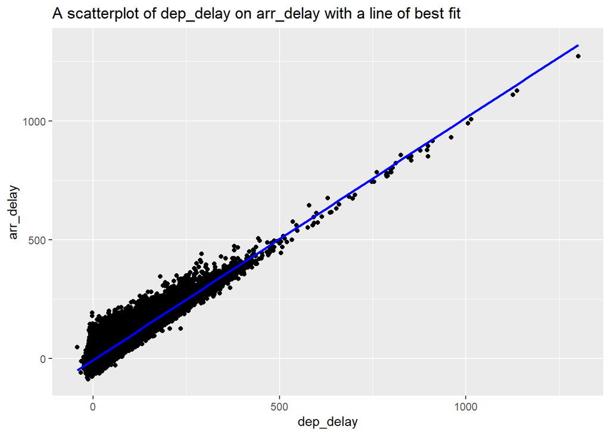

```r
general_plot <- function(df, x, y) {
  label <- rlang::englue("A scatterplot of {{x}} on {{y}} with a line of best fit")

  df |>
    ggplot(aes(x = {{ x }}, y = {{ y }})) +
    geom_point() +
    geom_smooth(method = "lm", formula = y ~ x, color = "blue", se = FALSE) +
    labs(title = label)
}

flights |>
  general_plot(dep_delay, arr_delay)
```

## Functions - Style

1. Read the source code for each of the following two functions, puzzle out what they do, and then brainstorm better names.

```r
f1 <- function(string, prefix) {
  str_sub(string, 1, str_length(prefix)) == prefix
}
# This function tells us whether a string has the following supplied prefix or not.

prefix <- "boo"
str_sub("hello", 1, str_length(prefix)) == prefix
```

```
## [1] FALSE
```

```r
str_sub("bootie", 1, str_length(prefix)) == prefix
```

```
## [1] TRUE
```

```r
# Maybe we can call it `has_prefix` or `is_prefix`

f3 <- function(x, y) {
  rep(y, length.out = length(x))
}
# This function repeats y by whatever length x is

x <- c(5, 3, 2, 1, 10)
y <- 1
f3(x, y)
```

```
## [1] 1 1 1 1 1
```

```r
# Maybe we can call it rep_y_by_x_length, but this seems kind of long.
```

2. Take a function that you’ve written recently and spend 5 minutes brainstorming a better name for it and its arguments.

```r
# I'm not sure since I haven't written my own function recently, so instead lets think about the f1 function above.

has_prefix <- function(string, prefix) {
  str_sub(string, 1, str_length(prefix)) == prefix
}
# The arguments seem perfectly fine.
```

3. Make a case for why norm_r(), norm_d() etc. would be better than rnorm(), dnorm(). Make a case for the opposite. How could you make the names even clearer?

```r
# If we specifically thought about wanting a normal distribution function that having them named `norm_r()`, `norm_d()` etc. would be better when using auto complete.
# The opposite may be true if we want to find a random (r) or density (d) distribution.
# We could potentially make the names even clearer by doing something like `rand_norm()`, `dens_norm()` etc. so there is no confusion what these functions are doing.
```